# Tema 5 (material que contiene elementos de solución del Ejercicio 4B)

Viacheslav Shalisko

15 de noviembre de 2018

# Simple mapa del Mundo

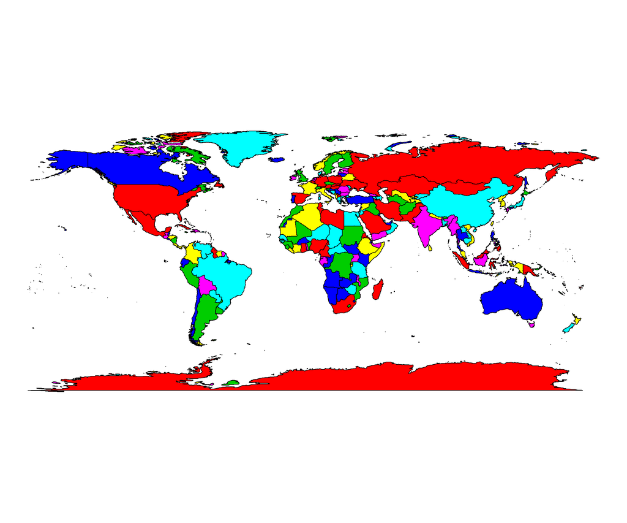

```r
library(maps)
map('world', fill = TRUE, col = 2:7)
```

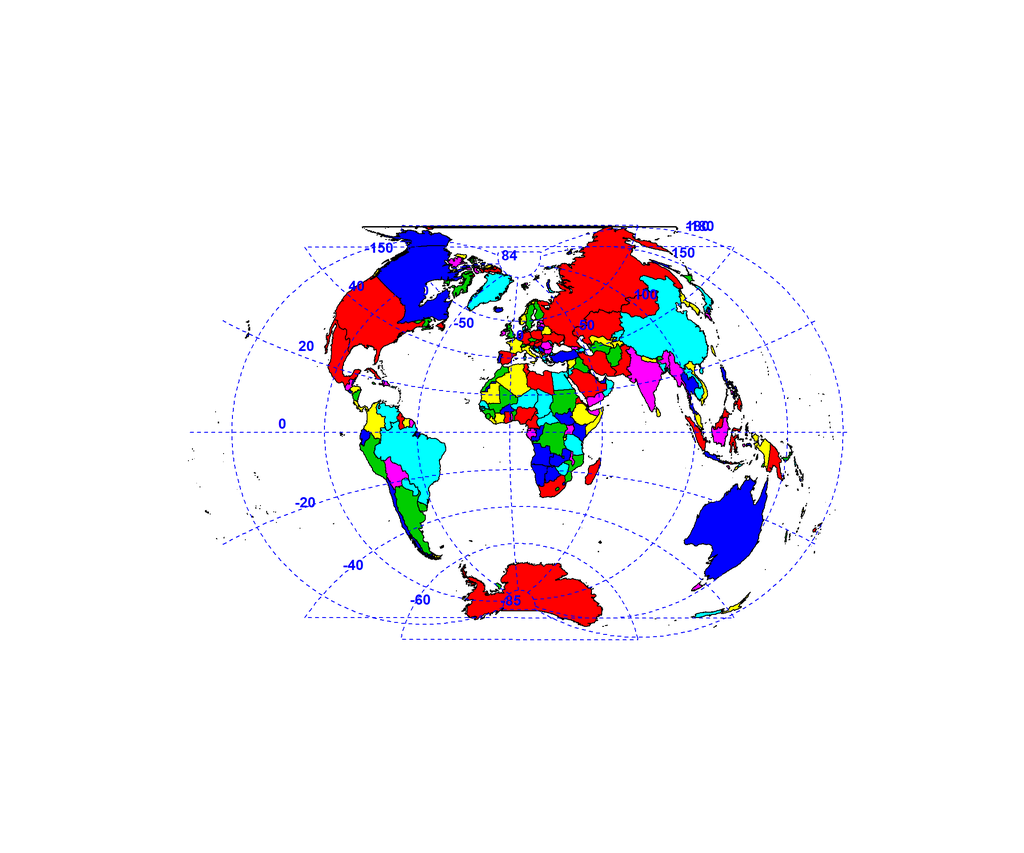

```r
# otra proyección y lineas de cuadrantes
library(mapproj)
map('world', fill = TRUE, col = 2:7, projection = "globular")
my_grid <- map('world', plot = FALSE)
map.grid(my_grid)
```

# Mapa de México y Centroamérica

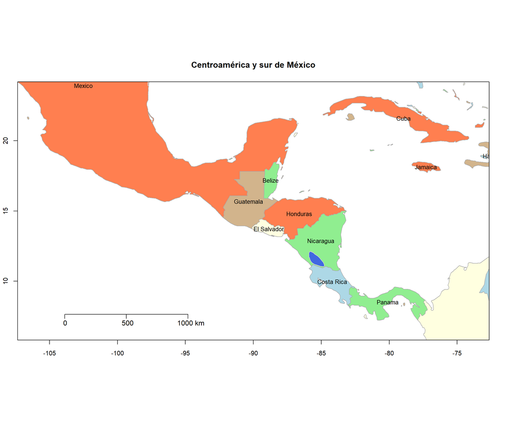

```r
# definir limites
ext_vector <- c(-107.008472222,-72.9807502222,5.99152777778,24.0179697778)

# mapa principal
my_map <- map('world', border = "darkgray", fill = TRUE,
              col = c("coral","lightgreen","lightyellow","lightblue","tan"),
              xlim = ext_vector[1:2], ylim = ext_vector[3:4])

# titulo, ejes y escala
title("Centroamérica y sur de México")
map.axes(cex.axis = 0.9)
map.scale(ratio = FALSE)

# agregar capa de lagos
map('lakes', add = TRUE, fill = TRUE, col = "royalblue", border = "lightgray")

# agregar nombres de paises, pero omitir islas y  otros fragmentos
my_names <- my_map$names
my_good_names <- my_names[!grepl(":+", my_names)]
map.text('world', regions = my_good_names, exact = TRUE,
         cex = 0.85, add = TRUE)
```

# Cargar los archivos shapefile y visualizarlos

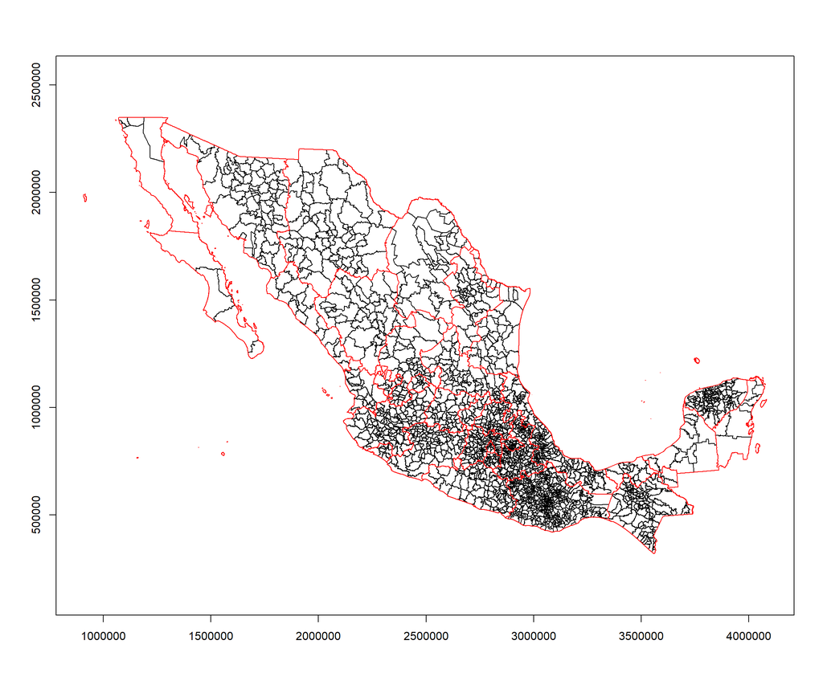

```r
#library(maptools)
#municipios <- readShapePoly("datos/Municipios.shp")    # obsleto
#estados <- readShapePoly("datos/Estados.shp")    # obsleto


library(sp)
library(rgdal)
municipios <- readOGR("datos/Municipios.shp")
estados <- readOGR("datos/Estados.shp")
plot(municipios, axes = TRUE)
plot(estados, border = "red", add = TRUE)
```

# Cuadro en proyección LCC de INEGI

Nota sobre proyeccion LCC usada por INEGI:  
De acuerdo con la descripción en la [Guía para asignar sistemas de coordenadas](http://www.inegi.org.mx/geo/contenidos/mapadigital/doc/asignar_sistema_coordenadas.pdf), la proyección LCC de INEGI cuenta con siguientes parámetros:

> Datum International Terrestrial Reference Frame 1992 (ITRF92 ) (epsg:6651)  
> Elipsoide GRS 1980 (epsg:7019)  
> Proyección Lambert Conformal Conic 2SP (epsg:9802)  
> Falso este 2500000  
> Falso norte 0  
> Paralelo estándar 1 17°30’0.00" N  
> Paralelo estándar 2 29°30’0.00" N  
> Meridiano central 102°00’0.00" W  
> Latitud origen 12° 00’0.00" W  
> Factor de escala 1  
> Unidad lineal Metros

Para propósitos prácticos se puede considerara que el Datum ITRF92 coincide con el datus WGS1984, ya que la diferencia entre estos datums en mayor parte de la Tierra no supera 10 cm (ftp://itrf.ensg.ign.fr/pub/itrf/WGS84.TXT).  
La cadena que empleamos para definir la proyección LCC de INEGI en este caso es `"+proj=lcc +lat_1=17.5 +lat_2=29.5 +lat_0=12 +lon_0=-102 +x_0=2500000 +y_0=0 +units=m +ellps=GRS80 +datum=WGS84"`.

```r
#library(maptools)
library(rgdal)
library(sp)



mi_crs <- CRS("+proj=lcc +lat_1=17.5 +lat_2=29.5 +lat_0=12 +lon_0=-102 +x_0=2500000 +y_0=0 +units=m +ellps=GRS80 +datum=WGS84")
estados_lcc <- readOGR("datos/Estados.shp",  encoding = "UTF-8")
proj4string(estados_lcc) <- mi_crs
estados_utf <- readOGR("datos/Estados.shp",  encoding = "UTF-8")
proj4string(estados_utf)
```

```
## [1] "+proj=lcc +lat_1=17.5 +lat_2=29.5 +lat_0=12 +lon_0=-102 +x_0=2500000 +y_0=0 +ellps=GRS80 +units=m +no_defs"
```

```r
levels(estados_utf$NOM_ENT)
```

```
##  [1] "Aguascalientes"                  "Baja California"
##  [3] "Baja California Sur"             "Campeche"
##  [5] "Chiapas"                         "Chihuahua"
##  [7] "Coahuila de Zaragoza"            "Colima"
##  [9] "Distrito Federal"                "Durango"
## [11] "Guanajuato"                      "Guerrero"
## [13] "Hidalgo"                         "Jalisco"
## [15] "México"                          "Michoacán de Ocampo"
## [17] "Morelos"                         "Nayarit"
## [19] "Nuevo León"                      "Oaxaca"
## [21] "Puebla"                          "Querétaro"
## [23] "Quintana Roo"                    "San Luis Potosí"
## [25] "Sinaloa"                         "Sonora"
## [27] "Tabasco"                         "Tamaulipas"
## [29] "Tlaxcala"                        "Veracruz de Ignacio de la Llave"
## [31] "Yucatán"                         "Zacatecas"
```

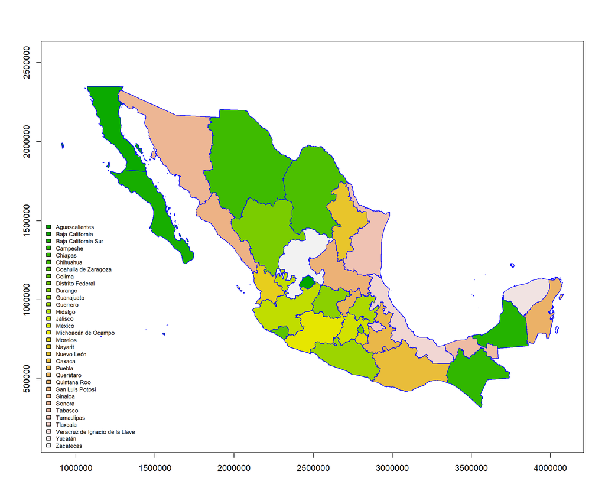

```r
palette(terrain.colors(32))
plot(estados_utf, axes = TRUE, border = "blue", col = estados_utf$NOM_ENT)
legend("bottomleft", legend = levels(estados_utf$NOM_ENT),
       fill = palette(terrain.colors(32)), bty = "n", cex = 0.7)
```

# Cuadro reproyectado a coordenadas geográficas con puntos de Guadalajara y Ciudad de México

## El ejercicio 4B tiene una solución similar

```r
library(rgdal)
library(sp)
library(maps)
library(GISTools)
mi_crs2 <- CRS("+proj=longlat +datum=WGS84 +ellps=WGS84 +towgs84=0,0,0")

estados_geo <- spTransform(estados_utf, mi_crs2)

lista_lat <- c(20.65,19.41)
lista_lon <- c(-103.35,-99.13)
puntos <- data.frame(lista_lon,lista_lat)
names(puntos) <- c("Longitud","Latitud")

puntos_sp <- SpatialPoints(puntos, proj4string = mi_crs2)
puntos_sp
```

```
## SpatialPoints:
##      Longitud Latitud
## [1,]  -103.35   20.65
## [2,]   -99.13   19.41
## Coordinate Reference System (CRS) arguments: +proj=longlat
## +datum=WGS84 +ellps=WGS84 +towgs84=0,0,0
```

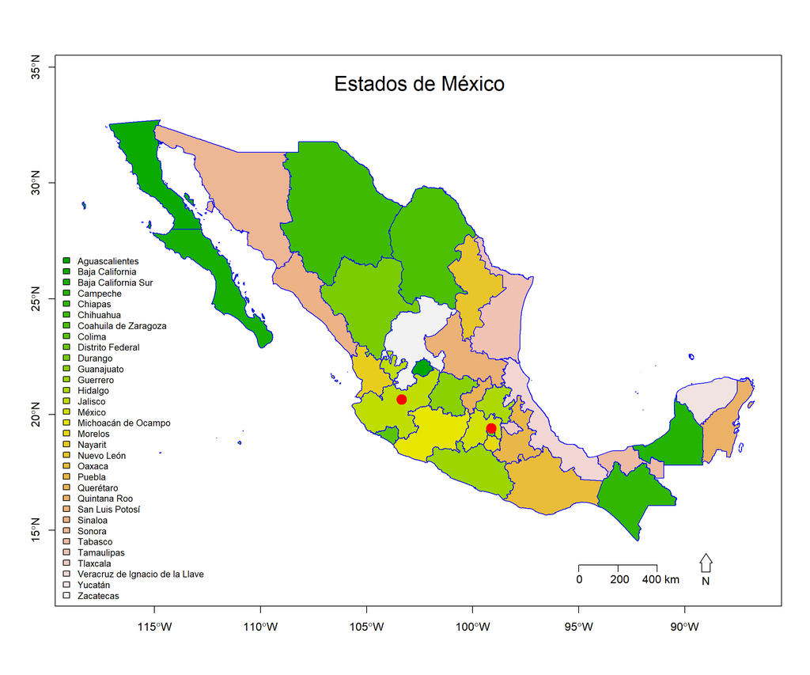

```r
plot(estados_geo, axes = TRUE, border = "blue", col = estados_geo$NOM_ENT)
points(puntos_sp$Longitud, puntos_sp$Latitud, pch = 19, col = "red", cex = 2)
legend("bottomleft", legend = levels(estados_geo$NOM_ENT),
       fill = palette(terrain.colors(32)), bty = "n", cex = 0.8)

maps::map.scale(-95, 13.5, relwidth = 0.1, ratio = FALSE)
north.arrow(-89, 13.2, 0.2, "N")
text(-102.5, 34, "Estados de México", cex = 1.8, adj = c(0.5,0))
```